# STAT167 HW5 - Spring 2021

#### (ii) [15pt] Mark all destination airports on a states map

Find out the coordinates of the destination airports from `nycflights13::airports`. Draw each destination airport as a point on a states map, and map a point aesthetic to the number of **non-canceled** flights flew to that destination from NYC in 2013.

**Hint:** Suppose that you have saved your list of unique destinations and their corresponding flight counts in a tibble called `per_dest`. Then you can *join* `per_dest` and `airports` using destination airport FAA code as the *key*.

```r
#?airports
per_dest <- # create per_dest by using not_canceled data group by carrier and dest then count
  not_canceled %>%
  group_by(carrier, dest) %>%
  count(carrier, dest)

airports %>% glimpse()
```

```
## Rows: 1,458
## Columns: 8
## $ faa   <chr> "04G", "06A", "06C", "06N", "09J", "0A9", "0G6", "0G7", "0P2"...
## $ name  <chr> "Lansdowne Airport", "Moton Field Municipal Airport", "Schaum...
## $ lat   <dbl> 41.13047, 32.46057, 41.98934, 41.43191, 31.07447, 36.37122, 4...
## $ lon   <dbl> -80.61958, -85.68003, -88.10124, -74.39156, -81.42778, -82.17...
## $ alt   <dbl> 1044, 264, 801, 523, 11, 1593, 730, 492, 1000, 108, 409, 875,...
## $ tz    <dbl> -5, -6, -6, -5, -5, -5, -5, -5, -5, -8, -5, -6, -5, -5, -5, -...
## $ dst   <chr> "A", "A", "A", "A", "A", "A", "A", "A", "U", "A", "A", "U", "...
## $ tzone <chr> "America/New_York", "America/Chicago", "America/Chicago", "Am...
```

```r
all_data <- left_join(per_dest, airports, by=c("dest"="faa")) # create a data frame from per_dest and airports
all_data # print to check
```

```
## # A tibble: 312 x 10
## # Groups:   carrier, dest [312]
##    carrier dest      n name                lat   lon   alt    tz dst   tzone
##    <chr>   <chr> <int> <chr>             <dbl> <dbl> <dbl> <dbl> <chr> <chr>
##  1 9E      ATL      56 Hartsfield Jacks~  33.6 -84.4  1026    -5 A     America/~
##  2 9E      AUS       2 Austin Bergstrom~  30.2 -97.7   542    -6 A     America/~
##  3 9E      AVL      10 Asheville Region~  35.4 -82.5  2165    -5 A     America/~
##  4 9E      BNA     452 Nashville Intl     36.1 -86.7   599    -6 A     America/~
##  5 9E      BOS     853 General Edward L~  42.4 -71.0    19    -5 A     America/~
##  6 9E      BTV       2 Burlington Intl    44.5 -73.2   335    -5 A     America/~
##  7 9E      BUF     789 Buffalo Niagara ~  42.9 -78.7   724    -5 A     America/~
##  8 9E      BWI     815 Baltimore Washin~  39.2 -76.7   146    -5 A     America/~
##  9 9E      CAE       3 Columbia Metropo~  33.9 -81.1   236    -5 A     America/~
## 10 9E      CHS     331 Charleston Afb I~  32.9 -80.0    45    -5 A     America/~
## # ... with 302 more rows
```

**ANSWER**

```
## Warning: Removed 10 rows containing missing values (geom_point).
```

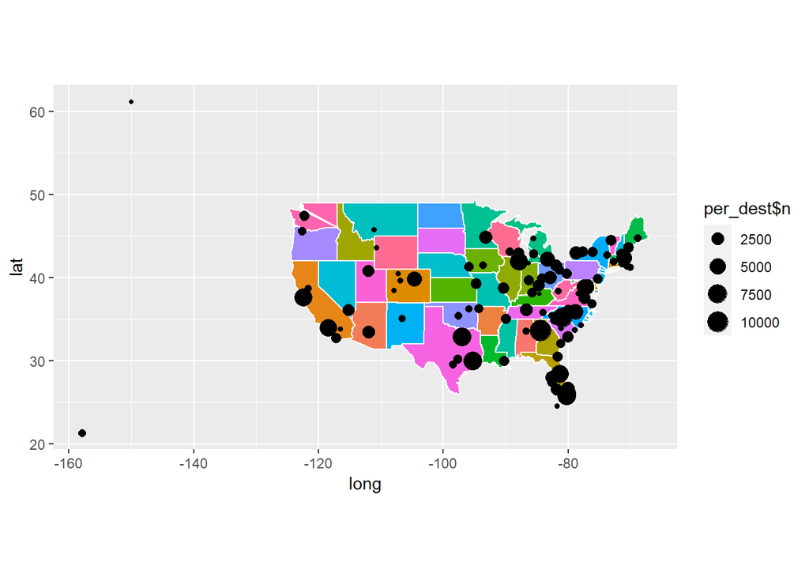

```r
# Graph polygon of states map with states white border, map points from all_data x = long y = lat size = count of each non canceled flight
ggplot() +
  geom_polygon(data = states_map, aes(x = long, y = lat, fill = region), color = "white") +
  expand_limits(x = states_map$long, y = states_map$lat) +
  geom_point(aes(x = all_data$lon, y = all_data$lat, size = per_dest$n)) +
  coord_quickmap() +
  guides(fill = FALSE)
```

Pay attention to the warning message. Which destination airports have missing values?

```r
# grop data by dest and then find missing values
all_data %>%
  group_by(dest) %>%
  filter(is.na(lon))
```

```
## # A tibble: 10 x 10
## # Groups:   dest [4]
##    carrier dest      n name    lat   lon   alt    tz dst   tzone
##    <chr>   <chr> <int> <chr> <dbl> <dbl> <dbl> <dbl> <chr> <chr>
##  1 AA      SJU    1085 <NA>     NA    NA    NA    NA <NA>  <NA>
##  2 AA      STT     301 <NA>     NA    NA    NA    NA <NA>  <NA>
##  3 B6      BQN     593 <NA>     NA    NA    NA    NA <NA>  <NA>
##  4 B6      PSE     358 <NA>     NA    NA    NA    NA <NA>  <NA>
##  5 B6      SJU    2709 <NA>     NA    NA    NA    NA <NA>  <NA>
##  6 DL      SJU    1294 <NA>     NA    NA    NA    NA <NA>  <NA>
##  7 DL      STT      29 <NA>     NA    NA    NA    NA <NA>  <NA>
##  8 UA      BQN     295 <NA>     NA    NA    NA    NA <NA>  <NA>
##  9 UA      SJU     685 <NA>     NA    NA    NA    NA <NA>  <NA>
## 10 UA      STT     188 <NA>     NA    NA    NA    NA <NA>  <NA>
```

```r
# There are four destinations with NA's. SJU, STT, BQN, and PSE.
```

## **Question 2 [55pt] Simple linear regression**

### (a) [10pt] Population regression line vs least squares regression line

In this question, we will reproduce the left panel of Figure 3.3 in the **ISLR** textbook.

Write your own R code the simulate 100 data points from the following model.

$$Y=2+3X+\epsilon$$
$$X \sim Uniform(A=-2, B=2)$$
$$\epsilon \sim N(\mu=0, \sigma=2)$$

Then use `ggplot2` to make a scatter plot of the 100 data points $(x_1,y_1), \cdots (x_{100},y_{100})$. Add the population regression line $Y=2+3X$ in red color; add the least squares fit of your simulated data as a blue line.

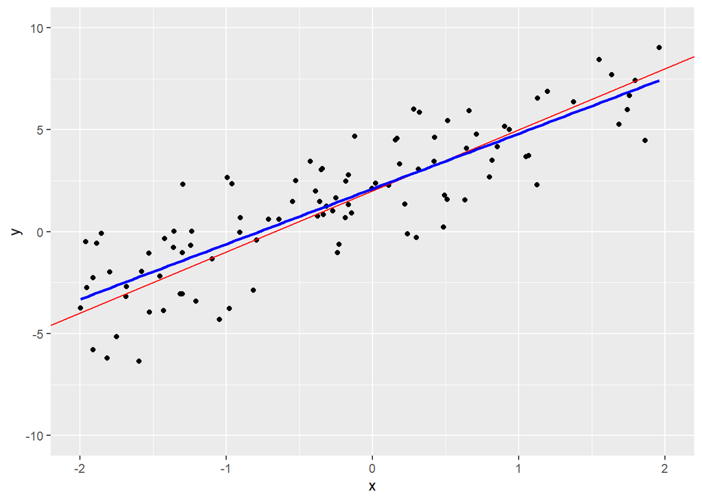

```r
# Always remember to set the random seed for simulation studies
set.seed(167) # feel free to change 167 to your lucky number
# generate x
x <- runif(100, -2, 2)
# generate e
e <- rnorm(100, 0, 2)
# calculate y
y <- 2 + 3*x + e
# make a dataframe of x and y
data1 <- as.data.frame(cbind(x,y))
# graph population regression line in red and least squares fit in blue
ggplot(data1, aes(x = x, y = y)) +
  geom_point() +
  geom_abline(slope = 3, intercept = 2, color = "red") +
  geom_smooth(method = "lm", se = F, color = "blue") +
  coord_cartesian(xlim = c(-2,2), y = c(-10,10))
## `geom_smooth()` using formula 'y ~ x'
```

### (b) [10pt] Estimate the coefficients $\beta_0$ and $\beta_1$

In the lecture, we have learned that the analytical solution of the least squares regression $Y = \beta_0 + \beta_1 X + \epsilon$ is

$$\begin{aligned}
\hat{\beta_1} & =
\frac{\sum_{i=1}^{n} (x_i - \bar{x})(y_i - \bar{y})}
{\sum_{i=1}^{n} (x_i - \bar{x})^2} \\
\hat{\beta_0} & = \bar{y} - \hat{\beta_1} \bar{x}
\end{aligned}$$

Write your own R code to calculate $\hat{\beta_0}$ and $\hat{\beta_1}$ using the above equations. Compare your results with the coefficients calculated by the `lm` function. Are they the same?

**ANSWER**

```r
# calculate beta1
b1 <- sum((x-mean(x))*(y-mean(y)))/(sum((x-mean(x))^2))
#calculate beta0
b0 <- mean(y)- b1*mean(x)
b1 # print
```

```
## [1] 2.711247
```

```r
b0 # print
```

```
## [1] 2.103547
```

```r
regress <- lm(y~x, data1) # save linear model of y to x
summary(regress) # print the summary
```

```
##
## Call:
## lm(formula = y ~ x, data = data1)
##
## Residuals:
##     Min      1Q  Median      3Q     Max
## -4.1423 -1.2995  0.2294  1.1943  3.7195
##
## Coefficients:
##             Estimate Std. Error t value Pr(>|t|)
## (Intercept)   2.1035     0.1855   11.34   <2e-16 ***
## x             2.7112     0.1672   16.22   <2e-16 ***
## ---
## Signif. codes:  0 '***' 0.001 '**' 0.01 '*' 0.05 '.' 0.1 ' ' 1
##
## Residual standard error: 1.8 on 98 degrees of freedom
## Multiple R-squared:  0.7286, Adjusted R-squared:  0.7258
## F-statistic:   263 on 1 and 98 DF,  p-value: < 2.2e-16
```

```r
# Yes, they are the same
```

### (c) [20pt] Assess accuracy of the regression model

Recall that the accuracy of a linear regression fit is typically assessed using the **residual standard error (RSE)** and the **$R^2$ statistic**.

#### (i) [10pt] Calculate the residual standard error (RSE)

Residual standard error (RSE) is an estimate of $\sigma$, the standard deviation of $\epsilon$.

$$\begin{aligned}
\text{RSE} = \hat{\sigma} &= \sqrt{\frac{1}{n-2}\text{RSS}} \\
&= \sqrt{\frac{1}{n-2} \sum_{i=1}^{n} ( y_i - \hat{y_i} )^2}
\end{aligned}$$
Write your own R code to calculate RSE using the above equation. Compare your result with the residual standard error calculated by the `lm` function. Are they the same? How does the RSE value relate to our noise model $\epsilon \sim N(\mu=0, \sigma=2)$?

```r
# calculate rss
rss <- sum((y-b0-b1*x)^2)
# calculate rse
rse <- sqrt((1/98)*rss)
rse # print rse
```

```
## [1] 1.79954
```

```r
summary(regress) # summary of regress
```

```
##
## Call:
## lm(formula = y ~ x, data = data1)
##
## Residuals:
##     Min      1Q  Median      3Q     Max
## -4.1423 -1.2995  0.2294  1.1943  3.7195
##
## Coefficients:
##             Estimate Std. Error t value Pr(>|t|)
## (Intercept)   2.1035     0.1855   11.34   <2e-16 ***
## x             2.7112     0.1672   16.22   <2e-16 ***
## ---
## Signif. codes:  0 '***' 0.001 '**' 0.01 '*' 0.05 '.' 0.1 ' ' 1
##
## Residual standard error: 1.8 on 98 degrees of freedom
## Multiple R-squared:  0.7286, Adjusted R-squared:  0.7258
## F-statistic:   263 on 1 and 98 DF,  p-value: < 2.2e-16
```

```r
# yes they are the same.
```

#### (ii) [10pt] Calculate the $R^2$ statistics

Write your own R code to compute the $R^2$ value using the following equations.

$$\begin{aligned}
\text{TSS} & = \sum_{i=1}^{n} (y_i - \bar{y})^2 \\
\text{RSS} & = \sum_{i=1}^{n} \left(y_i - \hat{f}(x_i) \right)^2 \\
R^2 & = \frac{\text{TSS}-\text{RSS}}{\text{TSS}} = 1 - \frac{\text{RSS}}{\text{TSS}} \\
\end{aligned}$$
Compare your result with the R-squared value calculated by the `lm` function. Are they the same?

```r
tss <- sum((y - mean(y))^2) # calcuate tss
rsquared <- (tss-rss)/tss # calculate rsquared
rsquared # print r squared
```

```
## [1] 0.7285655
```

```r
summary(regress) # print summary of linear model
```

```
##
## Call:
## lm(formula = y ~ x, data = data1)
##
## Residuals:
##     Min      1Q  Median      3Q     Max
## -4.1423 -1.2995  0.2294  1.1943  3.7195
##
## Coefficients:
##             Estimate Std. Error t value Pr(>|t|)
## (Intercept)   2.1035     0.1855   11.34   <2e-16 ***
## x             2.7112     0.1672   16.22   <2e-16 ***
## ---
## Signif. codes:  0 '***' 0.001 '**' 0.01 '*' 0.05 '.' 0.1 ' ' 1
##
## Residual standard error: 1.8 on 98 degrees of freedom
## Multiple R-squared:  0.7286, Adjusted R-squared:  0.7258
## F-statistic:   263 on 1 and 98 DF,  p-value: < 2.2e-16
```

```r
# They are the same
```

### (d) [15pt] Simulations of least squares regression

Now, let’s repeat the simulation 10 times, and reproduce the right panel of Figure 3.3 in the **ISLR** textbook.

**Notes**:

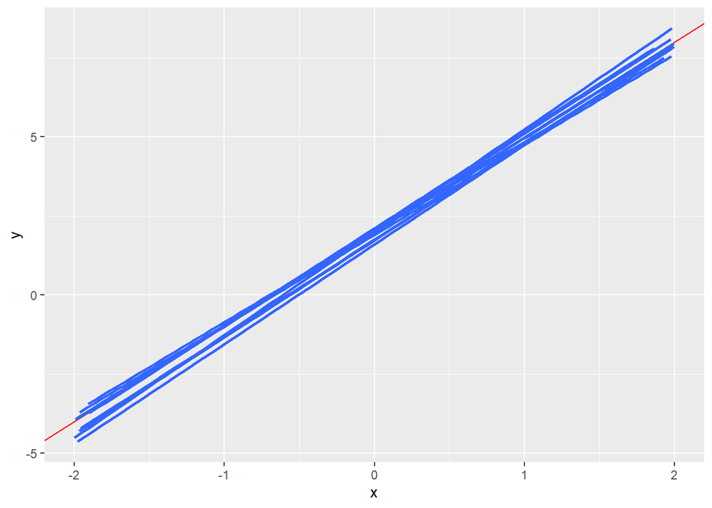

```r
# plot population regression line
gg <- ggplot() +
  geom_abline(slope = 3, intercept = 2, color = "red")
  #n <- 1

for ( i in 1:10 ) { # run for lop 10 times
  #n <-  n+1
  x <- runif(100, -2, 2) # calculate x
  e <- rnorm(100, 0, 2) # calculate e

  y <- 2 + 3*x + e # calculate y
  data2 <- as.data.frame(cbind(x,y)) # save data into a dataframe
  gg <- gg +  # plot data using linear model
    geom_smooth(data = data2, aes(x, y), method = "lm", se = F) ## alternatively you can use geom_abline()
}

gg ## call gg at the end to plot it.
```